# ROOT RDataFrame

[RDataFrame documentation](https://root.cern/doc/master/classROOT_1_1RDataFrame.html)

- RDF is ROOT's high-level analysis interface.
- Users define their analysis as a sequence of operations to be performed on the data-frame object;
  - the framework takes care of the management of the loop over entries as well as low-level details such as I/O and parallelisation.
- RDataFrame provides methods to perform most common operations required by ROOT analyses:
  - at the same time, users can just as easily specify custom code that will be executed in the event loop.

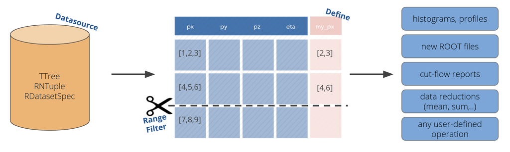

# HEP data analysis with RDataFrame

RDataFrame allows reading and writing trees, aiming at making HEP analysis easy to write and fast to perform.

```python
import ROOT

treename = "dataset"
filename = "../../data/example_file.root"
df = ROOT.RDataFrame(treename, filename)

print(f"Columns in the dataset: {df.GetColumnNames()}")
```

[output not shown]

Now we can `Define` new quantities, `Filter` rows based on custom expressions and retrieve some data aggregations such as a `Count` and a `Mean`:

```python
def1 = df.Define("c", "a+b")

fil1 = def1.Filter("c < 0.5")

count = fil1.Count()
mean = fil1.Mean("c")
display = fil1.Display(["a","b","c"])

print(f"Number of rows after filter: {count.GetValue()}")
print(f"Mean of column c after filter: {mean.GetValue()}")
print("Dataset contents:")
display.Print()
```

```
Number of rows after filter: 111
Mean of column c after filter: 0.38583512997804337
Dataset contents:
+-----+----------+----------+----------+
| Row | a        | b        | c        |
+-----+----------+----------+----------+
| 11  | 0.288436 | 0.042303 | 0.330739 |
+-----+----------+----------+----------+
| 13  | 0.256370 | 0.125539 | 0.381909 |
+-----+----------+----------+----------+
| 30  | 0.110457 | 0.317824 | 0.428281 |
+-----+----------+----------+----------+
| 92  | 0.265612 | 0.179740 | 0.445352 |
+-----+----------+----------+----------+
| 107 | 0.206094 | 0.175579 | 0.381673 |
+-----+----------+----------+----------+
```

# Histograms with RDataFrame

RDataFrame helps you streamline the creation and filling of histogram objects from your data.

For example:

```python
%jsroot on
c = ROOT.TCanvas()
h = df.Histo1D("vec1")
h.Draw()
c.Draw()
```

[output not shown]

- `Histo1D` will create a one-dimensional histogram holding `double` values.
- `Histo{2,3}D` do the same in higher dimensions.
- These operations also accept a tuple with the same arguments that would be passed to the equivalent histogram object constructors.
- For example:

```python
histo_name = "histo_name"
histo_title = "histo_title"
nbinsx = 100
xlow = -10
xup = 10

# The traditional TH1D constructor
# ROOT.TH1D(histo_name, histo_title, nbinsx, xlow, xup)

# With RDataFrame
c = ROOT.TCanvas()
h = df.Histo1D((histo_name, histo_title, nbinsx, xlow, xup), "vec1")
h.Draw()
c.Draw()
```

[output not shown]

# Think about data-flow

RDataFrame is built with a modular and flexible workflow in mind, summarised as follows:

- build a data-frame object by specifying your data-set
- apply a series of transformations to your data
  - filter (e.g. apply some cuts) or
  - define a new column (e.g. the result of an expensive computation on columns)
- apply actions to the transformed data to produce results (e.g. fill a histogram)

### Important Note!

Make sure to **book all transformations and actions before** you access the contents of any of the results: this lets RDataFrame accumulate work and then produce all results at the same time, upon first access to any of them.

```python
df_wrong = ROOT.RDataFrame(treename, filename)

h_a = df_wrong.Histo1D("a")
h_a_val = h_a.GetValue()

h_b = df_wrong.Histo1D("b")
h_b_val = h_b.GetValue()

h_vec1 = df_wrong.Histo1D("vec1")
h_vec1_val = h_vec1.GetValue()

print(f"The dataset was processed {df_wrong.GetNRuns()} times.")
```

```
The dataset was processed 3 times.
```

```python
df_good = ROOT.RDataFrame(treename, filename)

h_a = df_good.Histo1D("a")
h_b = df_good.Histo1D("b")
h_vec1 = df_good.Histo1D("vec1")

h_a_val = h_a.GetValue()
h_b_val = h_b.GetValue()
h_vec1_val = h_vec1.GetValue()

print(f"The dataset was processed {df_good.GetNRuns()} time.")
```

```
The dataset was processed 1 time.
```

# Operation categories in RDataFrame

There are 3 main types of operations you can perform on RDataFrames:

```python
%%html
<style>
  th { font-size: 30px }
  td { font-size: 30px }
</style>
```

**Transformations**: manipulate the dataset, return a modified RDataFrame for further processing.

| Transformation | Description |
| --- | --- |
| Alias() | Introduce an alias for a particular column name. |
| Define() | Creates a new column in the dataset. |
| Filter() | Filter rows based on user-defined conditions. |

**Actions**: aggregate (parts of) the dataset into a result.

| Action | Description |
| --- | --- |
| Count() | Return the number of events processed. |
| Display() | Provides a printable object representing the dataset contents. |
| Graph() | Fills a TGraph with the two columns provided. |
| Histo1D(), Histo2D(), Histo3D() | Fill a one-, two-, three-dimensional histogram with the processed column values. |
| Max(), Min() | Return the maximum(minimum) of processed column values. |
| Snapshot() | Writes processed data-set to a new TTree. |

[output not shown]

**Queries**: these methods query information about your dataset and the RDataFrame status.

| Operation | Description |
| --- | --- |
| GetColumnNames() | Get the names of all the available columns of the dataset. |
| GetColumnType() | Return the type of a given column as a string. |
| SaveGraph() | Export the computation graph of an RDataFrame in graphviz format for easy inspection. |
| ... | ... |